# Analysis of Road Accidents in Cities of India

SOUMYADEEP ADHIKARY

(HALDIA INSTITUTE OF TECHNOLOGY)

# INTRODUCTION

**” Roads and Highways are the backbone of connectivity in an economy “**

Road accidents in India takes away more than 90,000 lives a year.It is a major concern for developing countries like India.So a case study is made to analyse the pattern of road accidents in the cities of India.This type of case study will help Ministry of Road Transport and Highways and other goverment agencies to monitor the situation and take necessary steps.

Versions: Rstudio(2021.9.2.382) , R version 4.1.2(2021-11-01)

libraries used: *ggplot2*,*dplyr*,*superml*,*psych*

# Importing the libraries

```r
library(ggplot2)
library(dplyr)
library(superml)
library(psych)
```

# Loading the dataset

```r
train <- read.csv("Road_Accident.csv",header = TRUE)
```

# Printing sample data of 5 rows

```r
sample_n(train,5)
```

```
##     Name.of.City Total.number.of.Fatal.Accidents...2011 All.Accidents...2011
## 1 Tiruchirapalli                                     NA                   NA
## 2        Lucknow                                    493                 1270
## 3     Coimbatore                                    253                 1126
## 4           Agra                                    336                 1299
## 5          Delhi                                   2007                 7281
##   Persons.Killed...2011 Persons.Injured...2011
## 1                    NA                     NA
## 2                   517                    741
## 3                   259                   1058
## 4                   632                   1046
## 5                  2065                   7226
##   Total.number.of.Fatal.Accidents...2012 All.Accidents...2012
## 1                                    139                  778
## 2                                    474                 1202
```

[output cut: 51 more lines]

# To know the datatypes of variables of the dataset

```r
str(train)
```

```
## 'data.frame':    52 obs. of  30 variables:
##  $ Name.of.City                          : chr  "Agra" "Ahmedabad" "Asansol-Durgapur" "Aurangabad" ...
##  $ Total.number.of.Fatal.Accidents...2011: int  336 222 229 161 689 275 253 2007 74 229 ...
##  $ All.Accidents...2011                  : int  1299 2020 368 719 6031 3459 1126 7281 138 803 ...
##  $ Persons.Killed...2011                 : int  632 227 230 173 720 299 259 2065 82 249 ...
##  $ Persons.Injured...2011                : int  1046 2036 185 744 4952 2970 1058 7226 106 595 ...
##  $ Total.number.of.Fatal.Accidents...2012: int  381 245 199 178 707 278 263 1822 49 227 ...
##  $ All.Accidents...2012                  : int  922 1850 380 715 5508 3623 1128 6937 144 711 ...
##  $ Persons.Killed...2012                 : int  427 251 224 192 725 301 270 1866 54 247 ...
##  $ Persons.Injured...2012                : int  675 1845 315 649 4527 3076 1004 6633 191 537 ...
##  $ Fatal.Accidents...2013                : int  436 227 200 150 733 242 245 1778 223 205 ...
##  $ Total.Accidents...2013                : int  1008 1888 433 565 5215 3294 1300 7566 484 713 ...
##  $ Killed...2013                         : int  502 230 218 160 752 257 248 1820 248 215 ...
##  $ Injured...2013                        : int  750 1855 404 547 4334 2615 1138 7098 551 507 ...
##  $ Severity...2013                       : num  49.8 12.2 50.3 28.3 14.4 7.8 19.1 24.1 51.2 30.2 ...
```

[output cut: 16 more lines]

# To find missing values in the dataset

```r
lapply(train, function(x){length(which(is.na(x)))})
```

```
## $Name.of.City
## [1] 0
##
## $Total.number.of.Fatal.Accidents...2011
## [1] 13
##
## $All.Accidents...2011
## [1] 12
##
## $Persons.Killed...2011
## [1] 12
##
## $Persons.Injured...2011
## [1] 12
##
## $Total.number.of.Fatal.Accidents...2012
## [1] 1
##
## $All.Accidents...2012
## [1] 1
##
## $Persons.Killed...2012
## [1] 1
##
## $Persons.Injured...2012
## [1] 1
##
## $Fatal.Accidents...2013
## [1] 1
##
## $Total.Accidents...2013
## [1] 1
##
## $Killed...2013
## [1] 1
##
## $Injured...2013
## [1] 1
##
## $Severity...2013
```

[output cut: 34 more lines]

```
##
## $Non.Injurey.Accidents...2015
## [1] 1
##
## $Total.Accidents...2015
## [1] 1
##
## $Killed...2015
## [1] 1
##
## $Injured...2015
## [1] 1
##
## $Severity...2015
## [1] 1
```

# Eliminating the last row from the dataset

```r
train <- train[-c(52),]
```

# To have a summary of the dataset

```r
print(summary(train))
```

```
##  Name.of.City       Total.number.of.Fatal.Accidents...2011 All.Accidents...2011
##  Length:51          Min.   :  52.0                         Min.   :  138.0
##  Class :character   1st Qu.: 165.8                         1st Qu.:  650.5
##  Mode  :character   Median : 237.5                         Median : 1231.0
##                     Mean   : 316.4                         Mean   : 2284.3
##                     3rd Qu.: 393.8                         3rd Qu.: 2025.0
##                     Max.   :2007.0                         Max.   :25471.0
##                     NA's   :13                             NA's   :12
##  Persons.Killed...2011 Persons.Injured...2011
##  Min.   :  55.0        Min.   :  69.0
##  1st Qu.: 172.5        1st Qu.: 625.5
##  Median : 249.0        Median :1042.0
##  Mean   : 333.9        Mean   :1595.3
##  3rd Qu.: 416.0        3rd Qu.:2022.0
##  Max.   :2065.0        Max.   :7226.0
##  NA's   :12            NA's   :12
##  Total.number.of.Fatal.Accidents...2012 All.Accidents...2012
##  Min.   :  49.0                         Min.   :  144.0
##  1st Qu.: 158.0                         1st Qu.:  730.8
##  Median : 250.5                         Median : 1190.5
##  Mean   : 323.8                         Mean   : 2208.8
##  3rd Qu.: 386.2                         3rd Qu.: 1963.8
##  Max.   :1822.0                         Max.   :24592.0
##  NA's   :1                              NA's   :1
##  Persons.Killed...2012 Persons.Injured...2012 Fatal.Accidents...2013
##  Min.   :  54.0        Min.   :  71.0         Min.   :  55.0
##  1st Qu.: 168.0        1st Qu.: 592.0         1st Qu.: 155.5
##  Median : 266.0        Median : 977.5         Median : 246.0
##  Mean   : 339.1        Mean   :1619.3         Mean   : 321.7
##  3rd Qu.: 407.8        3rd Qu.:1893.0         3rd Qu.: 386.8
##  Max.   :1866.0        Max.   :8628.0         Max.   :1778.0
##  NA's   :1             NA's   :1              NA's   :1
##  Total.Accidents...2013 Killed...2013    Injured...2013   Severity...2013
##  Min.   :  135.0        Min.   :  58.0   Min.   :  76.0   Min.   : 2.1
##  1st Qu.:  697.8        1st Qu.: 165.5   1st Qu.: 628.8   1st Qu.:12.8
##  Median : 1234.0        Median : 261.0   Median : 987.0   Median :20.5
##  Mean   : 2203.8        Mean   : 340.1   Mean   :1607.6   Mean   :25.7
##  3rd Qu.: 1983.5        3rd Qu.: 409.8   3rd Qu.:1806.0   3rd Qu.:39.5
##  Max.   :23512.0        Max.   :1820.0   Max.   :8700.0   Max.   :72.6
##  NA's   :1              NA's   :1        NA's   :1        NA's   :1
```

[output cut: 33 more lines]

```
##  Min.   :    0.00             Min.   :  114.0        Min.   :  48.0
##  1st Qu.:   27.75             1st Qu.:  694.8        1st Qu.: 168.5
##  Median :   88.00             Median : 1336.0        Median : 260.5
##  Mean   :  585.40             Mean   : 2220.5        Mean   : 330.3
##  3rd Qu.:  270.25             3rd Qu.: 2176.8        3rd Qu.: 424.2
##  Max.   :19635.00             Max.   :23468.0        Max.   :1622.0
##  NA's   :1                    NA's   :1              NA's   :1
##  Injured...2015   Severity...2015
##  Min.   :  89.0   Min.   : 2.60
##  1st Qu.: 672.2   1st Qu.:12.80
##  Median :1049.0   Median :20.30
##  Mean   :1644.4   Mean   :24.79
##  3rd Qu.:1717.2   3rd Qu.:39.00
##  Max.   :8258.0   Max.   :66.00
##  NA's   :1        NA's   :1
```

# Filling the missing values using median values of each variable column

```r
for (i in 2:30) { x=median(train[,i],na.rm = TRUE)
  train[,i][is.na(train[,i])] <- x

}
```

# Encoding the first variable of the dataset

```r
label <- LabelEncoder$new()
train$Name.of.City <- label$fit_transform(train$Name.of.City)
```

# Decoding the first variable

```r
decode_names <- label$inverse_transform(train$Name.of.City)
decode_names
```

```
##  [1] "Agra"             "Ahmedabad"        "Asansol-Durgapur" "Aurangabad"
##  [5] "Bengaluru"        "Bhopal"           "Coimbatore"       "Delhi"
##  [9] "Dhanbad"          "Faridabad"        "Ghaziabad"        "Gwalior"
## [13] "Hyderabad"        "Indore"           "Jaipur"           "Jabalpur"
## [17] "Jamshedpur"       "Jodhpur"          "Kochi"            "Kolkata"
## [21] "Kollam"           "Kota"             "Kannur"           "Lucknow"
## [25] "Ludhiana"         "Madurai"          "Mallapuram"       "Mumbai"
## [29] "Meerut"           "Nagpur"           "Patna"            "Pune"
## [33] "Rajkot"           "Surat"            "Srinagar"         "Thrissur"
## [37] "Vadodra"          "Varanasi"         "Visakhapatnam"    "Allahabad"
## [41] "Amritsar"         "Chandigarh"       "Chennai"          "Kanpur"
## [45] "Khozikode"        "Nashik"           "Raipur"           "Thiruvanthapuram"
## [49] "Tiruchirapalli"   "Vijaywada City"   "Vizaq"
```

# Adding new variables to the dataset

```r
train$total_fatal_accidents <- train$Total.number.of.Fatal.Accidents...2011 +
  train$Total.number.of.Fatal.Accidents...2012 +
  train$Fatal.Accidents...2013+ train$Fatal.Accidents...2014+
  train$Fatal.Accidents...2015

train$total_accidents <- train$All.Accidents...2011 + train$All.Accidents...2012+
  train$Total.Accidents...2013 + train$Total.Accidents...2014 +train$Total.Accidents...2015

train$total_person_killed <- train$Persons.Killed...2011 +train$Persons.Killed...2012+
  train$Killed...2013 + train$Killed...2014 + train$Killed...2015

train$total_person_injured <- train$Persons.Injured...2011 + train$Persons.Injured...2012
 + train$Injured...2013 + train$Injured...2014 + train$Injured...2015
```

# Classifying total_person_killed into groups(“High”,“Moderate”,“Low”)

## Calculating percentile of total_person_killed

```r
Percentile_00  = min(train$total_person_killed)
Percentile_33  = quantile(train$total_person_killed, 0.33333)
Percentile_67  = quantile(train$total_person_killed, 0.66667)
Percentile_100 = max(train$total_person_killed)

RB = rbind(Percentile_00, Percentile_33, Percentile_67, Percentile_100)

dimnames(RB)[[2]] = "Value"

RB
```

```
##                   Value
## Percentile_00   318.000
## Percentile_33   964.663
## Percentile_67  1737.672
## Percentile_100 9044.000
```

## Creating a column classifying persons_killed

```r
train$total_person_killed_class[train$total_person_killed >= Percentile_00 & train$total_person_killed <  Percentile_33]  = "Low"
train$total_person_killed_class[train$total_person_killed >= Percentile_33 & train$total_person_killed <  Percentile_67]  = "Moderate"
train$total_person_killed_class[train$total_person_killed >= Percentile_67 & train$total_person_killed <= Percentile_100] = "High"
```

# Classifying total_person_injured into groups(“High”,“Moderate”,“Low”)

## Calculating percentile of total_person_injured

```r
Percentile_00  = min(train$total_person_injured)
Percentile_33  = quantile(train$total_person_injured, 0.33333)
Percentile_67  = quantile(train$total_person_injured, 0.66667)
Percentile_100 = max(train$total_person_injured)

RB = rbind(Percentile_00, Percentile_33, Percentile_67, Percentile_100)

dimnames(RB)[[2]] = "Value"

RB
```

```
##                    Value
## Percentile_00    229.000
## Percentile_33   1521.997
## Percentile_67   2654.360
## Percentile_100 13859.000
```

## Creating a column classifying persons_injured

```r
train$total_person_injured_class[train$total_person_injured >= Percentile_00 & train$total_person_injured <  Percentile_33]  = "Low"
train$total_person_injured_class[train$total_person_injured >= Percentile_33 & train$total_person_injured <  Percentile_67]  = "Moderate"
train$total_person_injured_class[train$total_person_injured >= Percentile_67 & train$total_person_injured <= Percentile_100] = "High"
```

# Classifying total_fatal_accidents into groups(“High”,“Moderate”,“Low”)

## Calculating percentile of total_fatal_accidents

```r
Percentile_00  = min(train$total_fatal_accidents)
Percentile_33  = quantile(train$total_fatal_accidents, 0.33333)
Percentile_67  = quantile(train$total_fatal_accidents, 0.66667)
Percentile_100 = max(train$total_fatal_accidents)

RB = rbind(Percentile_00, Percentile_33, Percentile_67, Percentile_100)

dimnames(RB)[[2]] = "Value"

RB
```

```
##                    Value
## Percentile_00   318.0000
## Percentile_33   914.9992
## Percentile_67  1644.1712
## Percentile_100 8818.0000
```

```r
train$total_fatal_accidents_class[train$total_fatal_accidents >= Percentile_00 & train$total_fatal_accidents <  Percentile_33]  = "Low"
train$total_fatal_accidents_class[train$total_fatal_accidents >= Percentile_33 & train$total_fatal_accidents <  Percentile_67]  = "Moderate"
train$total_fatal_accidents_class[train$total_fatal_accidents >= Percentile_67 & train$total_fatal_accidents <= Percentile_100] = "High"
```

# Printing most important columns of the dataset for analysis

```r
select(train,31:37)
```

```
##    total_fatal_accidents total_accidents total_person_killed
## 1                 2056.0          5367.0                2538
## 2                 1268.0          9237.0                1298
## 3                 1033.0          2070.0                1092
## 4                  803.0          3213.0                 865
## 5                 3540.0         26592.0                3639
## 6                 1216.0         17456.0                1328
## 7                 1271.0          6661.0                1304
## 8                 8818.0         38492.0                9044
## 9                  448.0           986.0                 495
## 10                1113.0          3615.0                1176
## 11                1902.0          4556.0                2037
## 12                1127.0         10037.0                1212
## 13                2177.0         13488.0                2234
## 14                2045.0         27601.0                2177
```

[output cut: 141 more lines]

# Printing data according to the year

```r
select(train,contains("2011"))
```

```
##    Total.number.of.Fatal.Accidents...2011 All.Accidents...2011
## 1                                   336.0                 1299
## 2                                   222.0                 2020
## 3                                   229.0                  368
## 4                                   161.0                  719
## 5                                   689.0                 6031
## 6                                   275.0                 3459
## 7                                   253.0                 1126
## 8                                  2007.0                 7281
## 9                                    74.0                  138
## 10                                  229.0                  803
## 11                                  495.0                 1109
## 12                                  233.0                 2030
## 13                                  428.0                 2651
## 14                                  407.0                 4995
```

[output cut: 89 more lines]

```r
select(train,contains("2012"))
```

```
##    Total.number.of.Fatal.Accidents...2012 All.Accidents...2012
## 1                                   381.0                922.0
## 2                                   245.0               1850.0
## 3                                   199.0                380.0
## 4                                   178.0                715.0
## 5                                   707.0               5508.0
## 6                                   278.0               3623.0
## 7                                   263.0               1128.0
## 8                                  1822.0               6937.0
## 9                                    49.0                144.0
## 10                                  227.0                711.0
## 11                                  358.0                850.0
## 12                                  213.0               1974.0
## 13                                  433.0               2577.0
## 14                                  419.0               5433.0
```

[output cut: 89 more lines]

```r
select(train,contains("2013"))
```

```
##    Fatal.Accidents...2013 Total.Accidents...2013 Killed...2013 Injured...2013
## 1                     436                   1008           502            750
## 2                     227                   1888           230           1855
## 3                     200                    433           218            404
## 4                     150                    565           160            547
## 5                     733                   5215           752           4334
## 6                     242                   3294           257           2615
## 7                     245                   1300           248           1138
## 8                    1778                   7566          1820           7098
## 9                     223                    484           248            551
## 10                    205                    713           215            507
## 11                    363                    874           406            667
## 12                    232                   1934           247           1470
## 13                    482                   2591           493           2237
## 14                    388                   5516           422           4407
```

[output cut: 89 more lines]

```r
select(train,contains("2014"))
```

```
##    Fatal.Accidents...2014 Greviously.Injured.Accidents...2014
## 1                   405.0                               432.0
## 2                   256.0                               263.0
## 3                   195.0                               167.0
## 4                   161.0                               254.0
## 5                   703.0                              1385.0
## 6                   199.0                               127.0
## 7                   272.0                               404.0
## 8                  1629.0                               352.0
## 9                    60.0                                32.0
## 10                  253.0                               127.0
## 11                  370.0                               421.0
## 12                  200.0                               135.0
## 13                  409.0                               252.0
## 14                  410.0                               311.0
```

[output cut: 141 more lines]

```r
select(train,contains("2015"))
```

```
##    Fatal.Accidents...2015 Greviously.Injured.Accidents...2015
## 1                     498                                 369
## 2                     318                                 351
## 3                     210                                 160
## 4                     153                                 297
## 5                     708                                1331
## 6                     222                                 207
## 7                     238                                 483
## 8                    1582                                 372
## 9                      42                                  48
## 10                    199                                  92
## 11                    316                                 430
## 12                    249                                 118
## 13                    425                                 484
## 14                    421                                 322
```

[output cut: 141 more lines]

# Making visualisation of dataset

## Making visualisation of total_accidents along with total_person_killed_class

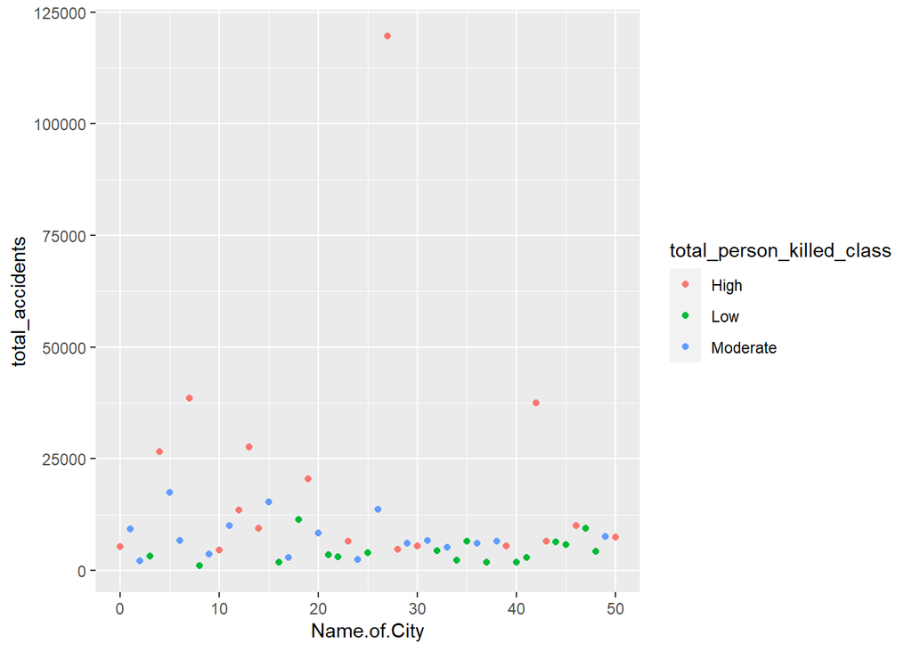

```r
ggplot(data = train) +
  geom_point(mapping = aes(x = Name.of.City, y = total_accidents, color = total_person_killed_class))
```

## Making visualisation of total_accidents along with total_fatal_accidents_class

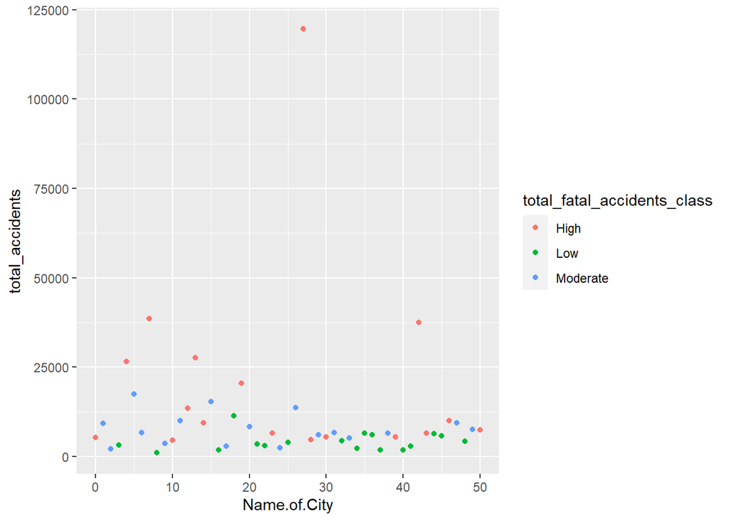

```r
ggplot(data = train) +
  geom_point(mapping = aes(x = Name.of.City, y = total_accidents, color = total_fatal_accidents_class))
```

## Making visualisation of total_accidents along with total_person_injured_class

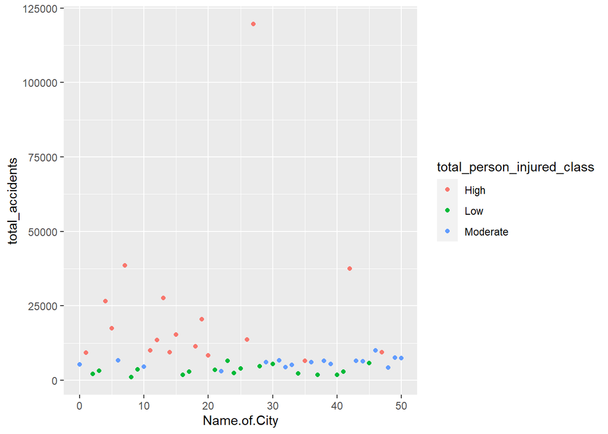

```r
ggplot(data = train) +
  geom_point(mapping = aes(x = Name.of.City, y = total_accidents, color = total_person_injured_class))
```

## Making visualisation with more details

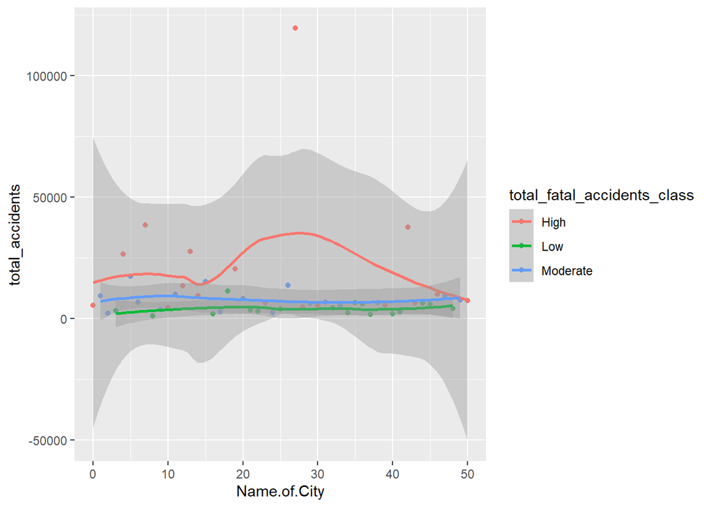

```r
ggplot(data = train) +
  geom_point(mapping = aes(x = Name.of.City, y = total_accidents,color = total_fatal_accidents_class)) +
  geom_smooth(mapping = aes(x = Name.of.City, y = total_accidents,color = total_fatal_accidents_class))
```

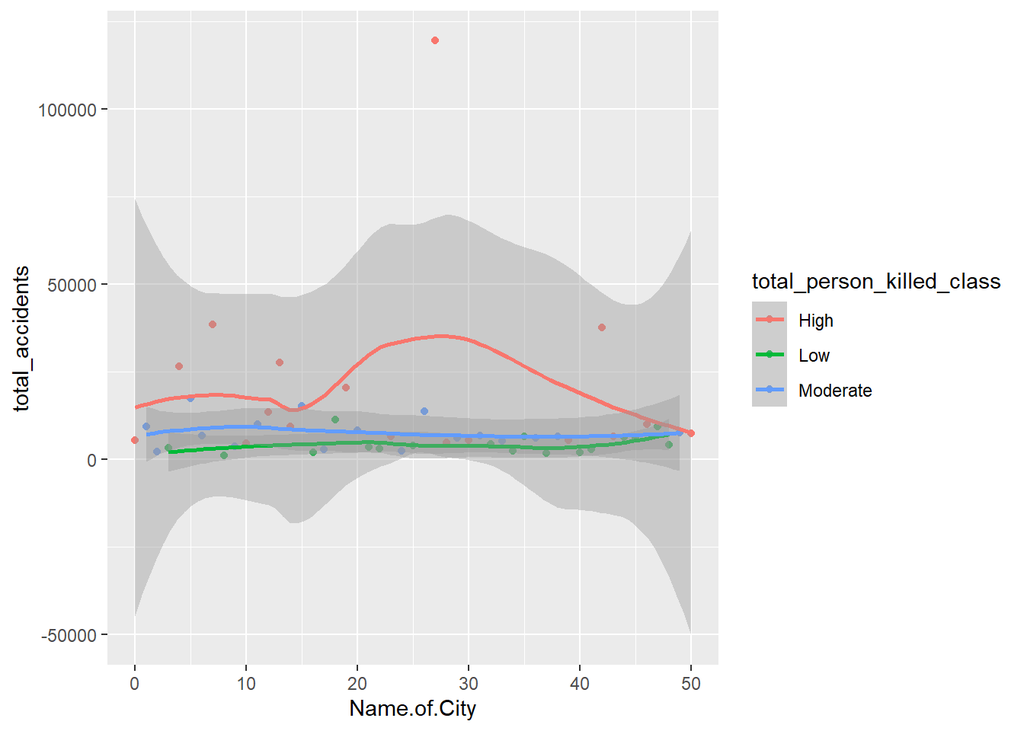

```r
ggplot(data = train) +
  geom_point(mapping = aes(x = Name.of.City, y = total_accidents,color = total_person_killed_class)) +
  geom_smooth(mapping = aes(x = Name.of.City, y = total_accidents,color = total_person_killed_class))
```

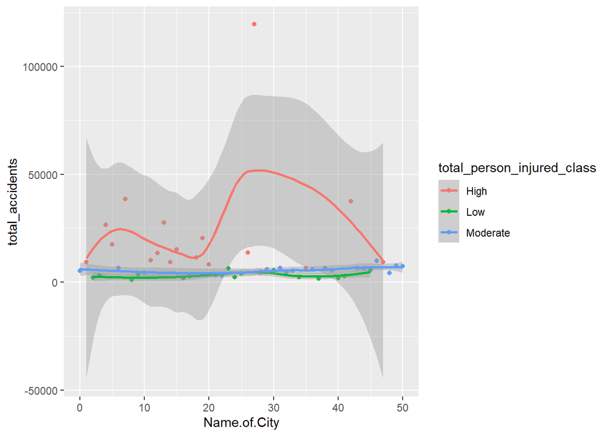

```r
ggplot(data = train) +
  geom_point(mapping = aes(x = Name.of.City, y = total_accidents,color = total_person_injured_class)) +
  geom_smooth(mapping = aes(x = Name.of.City, y = total_accidents,color = total_person_injured_class))
```

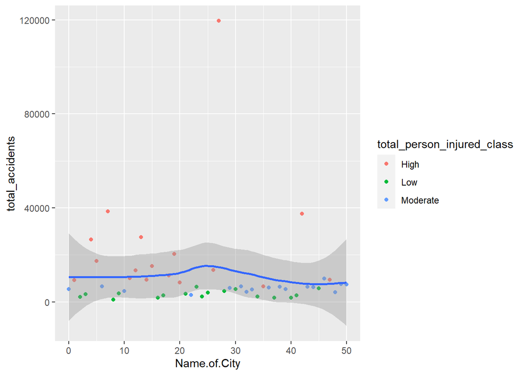

```r
ggplot(data = train, mapping = aes(x = Name.of.City, y = total_accidents)) +
  geom_point(mapping = aes(color = total_person_injured_class)) +
  geom_smooth()
```

## Making bar_charts of the dataset

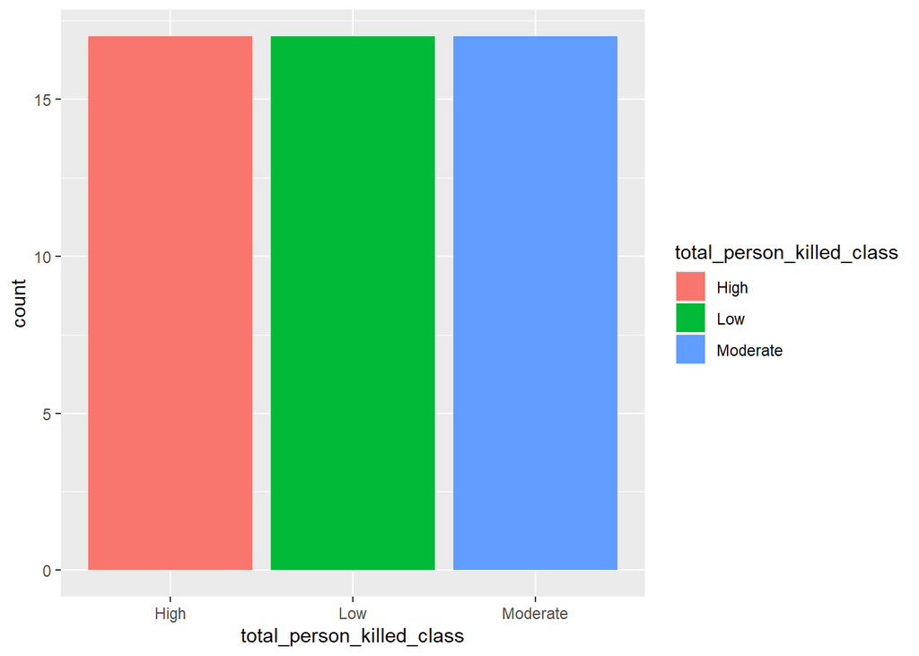

```r
ggplot(data = train) +
  geom_bar(mapping = aes(x = total_person_killed_class, fill = total_person_killed_class))
```

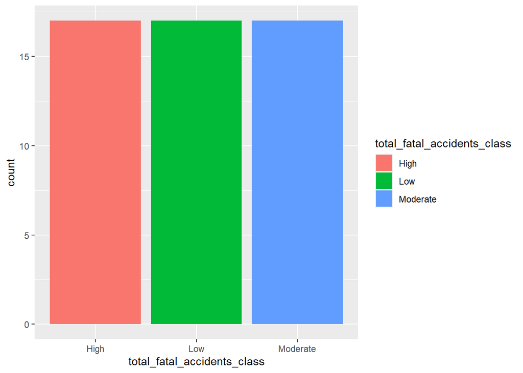

```r
ggplot(data = train) +
  geom_bar(mapping = aes(x = total_fatal_accidents_class,fill = total_fatal_accidents_class))
```

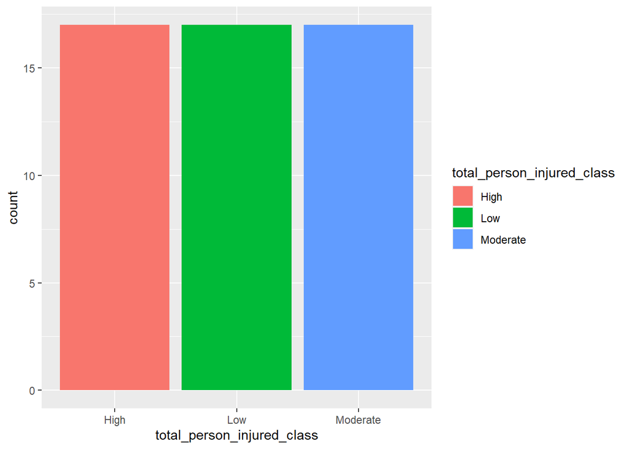

```r
ggplot(data = train) +
  geom_bar(mapping = aes(x = total_person_injured_class, fill =total_person_injured_class))
```

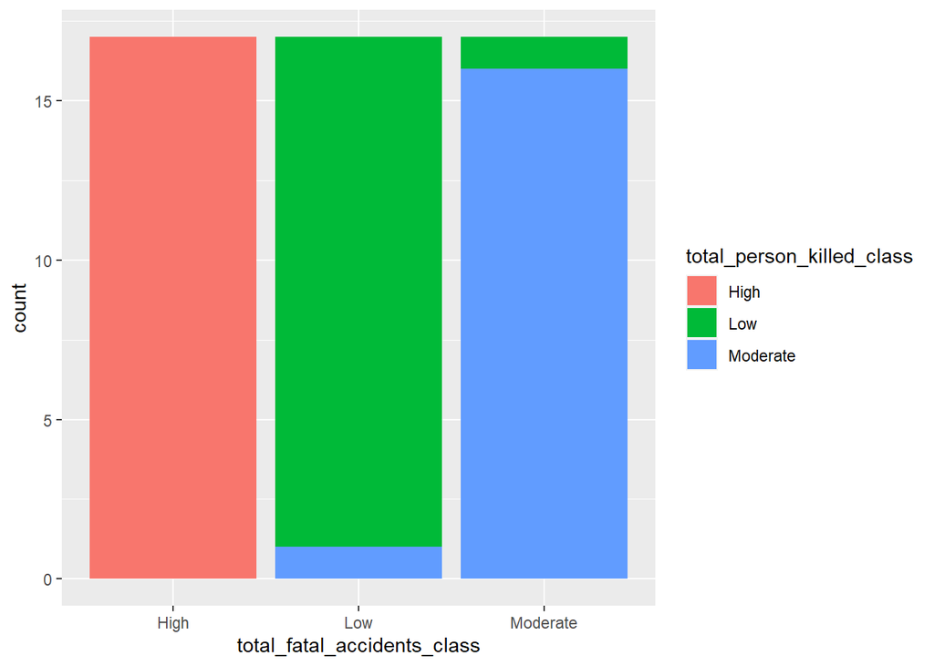

```r
ggplot(data = train) +
  geom_bar(mapping = aes(x = total_fatal_accidents_class, fill = total_person_killed_class))
```

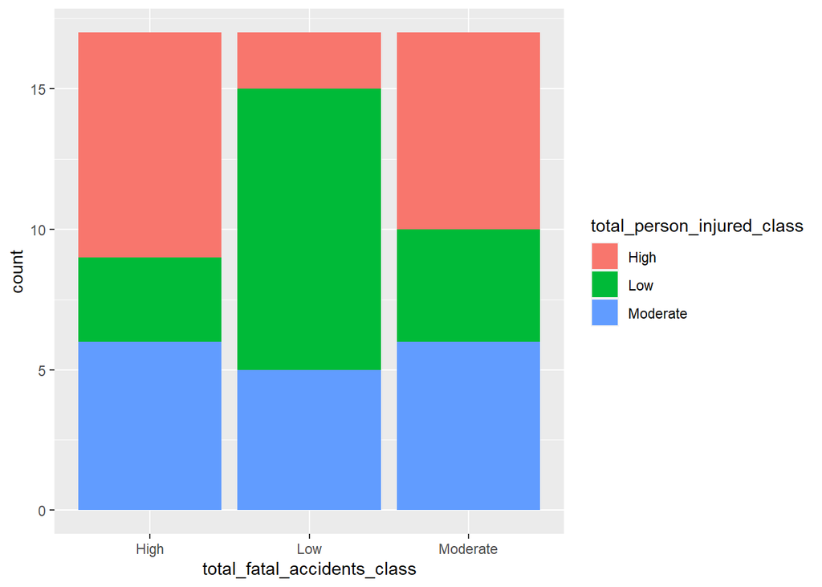

```r
ggplot(data = train) +
  geom_bar(mapping = aes(x = total_fatal_accidents_class, fill = total_person_injured_class))
```

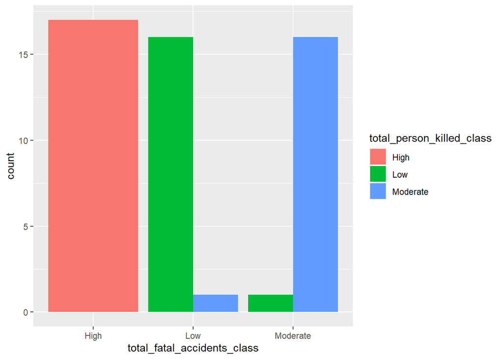

```r
ggplot(data = train) +
   geom_bar(mapping = aes(x = total_fatal_accidents_class, fill = total_person_killed_class), position = "dodge")
```

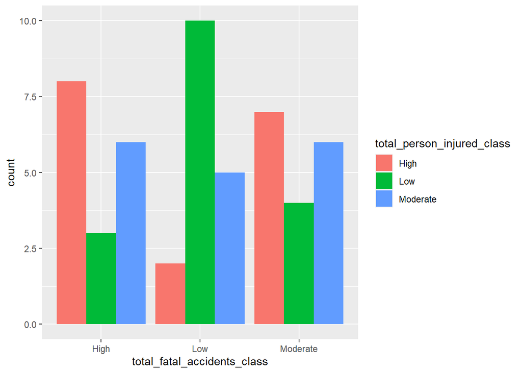

```r
ggplot(data = train) +
   geom_bar(mapping = aes(x = total_fatal_accidents_class, fill = total_person_injured_class), position = "dodge")
```

# Results and Discussions

It is observed that cities like **Delhi**,**Bengaluru**,**Indore**,**Mumbai**,**Chennai** has highest accident rate along with high fatal accidents rate and high person killed rate.On the other hand cities like **Dhanbad**,**Jamshedpur**,**Srinagar**,**Varanasi**, **Amritsar** has lowest accident rate.

From the above observation it is clear that **metropoliton** cities has highest accident rate.

From the results obtained we found some cities like **Agra**,**Ghaziabad**,**Lucknow**, **Patna**,**Meerut**,**Allahabad** and **Kanpur** inspite of having low accident rate those cities has high fatal accident rate as well as high person killed rate.

So it can be said that those cities might be less populated and accidents occuring is very severe.The transportation system in this cities may be very bad or hospital facilities in this cities are bad due to which person killed rate is high.

From the visualisation it is seen that total fatal accidents is directly proportional to total person killed.

# Conclusion

We know that transportation through roads and highways is very important as it helps our economy grow.Also we should ensure safety measures while traveling through this roads.The government and other agencies should look after this matter as it involves life of people and take necessary actions.

# Reference

Data source link,https://data.gov.in/node/1895961/download

Classification of Indian Cities, https://en.wikipedia.org/wiki/Classification_of_Indian_cities